# HR Analysis: Employee Attrition & Insights

```python
import pandas as pd
import matplotlib.pyplot as plt
import seaborn as sns
```

```python
df=pd.read_csv("C:/Users/CompuMisr/Downloads/hr")
```

```python
pd.set_option('display.max_columns', None)
```

```python
df.head(3)
```

|  | Age | Attrition | BusinessTravel | DailyRate | Department | DistanceFromHome | Education | EducationField | EmployeeCount | EmployeeNumber | EnvironmentSatisfaction | Gender | HourlyRate | JobInvolvement | JobLevel | JobRole | JobSatisfaction | MaritalStatus | MonthlyIncome | MonthlyRate | NumCompaniesWorked | Over18 | OverTime | PercentSalaryHike | PerformanceRating | RelationshipSatisfaction | StandardHours | StockOptionLevel | TotalWorkingYears | … |
| --- | --- | --- | --- | --- | --- | --- | --- | --- | --- | --- | --- | --- | --- | --- | --- | --- | --- | --- | --- | --- | --- | --- | --- | --- | --- | --- | --- | --- | --- | --- |
| 0 | 41 | Yes | Travel_Rarely | 1102 | Sales | 1 | 2 | Life Sciences | 1 | 1 | 2 | Female | 94 | 3 | 2 | Sales Executive | 4 | Single | 5993 | 19479 | 8 | Y | Yes | 11 | 3 | 1 | 80 | 0 | 8 | … |
| 1 | 49 | No | Travel_Frequently | 279 | Research & Development | 8 | 1 | Life Sciences | 1 | 2 | 3 | Male | 61 | 2 | 2 | Research Scientist | 2 | Married | 5130 | 24907 | 1 | Y | No | 23 | 4 | 4 | 80 | 1 | 10 | … |
| 2 | 37 | Yes | Travel_Rarely | 1373 | Research & Development | 2 | 2 | Other | 1 | 4 | 4 | Male | 92 | 2 | 1 | Laboratory Technician | 3 | Single | 2090 | 2396 | 6 | Y | Yes | 15 | 3 | 2 | 80 | 0 | 7 | … |

# Question 1: What is the overall employee attrition rate in the company?

```
Employee Attrition Rate: 16.12%
```

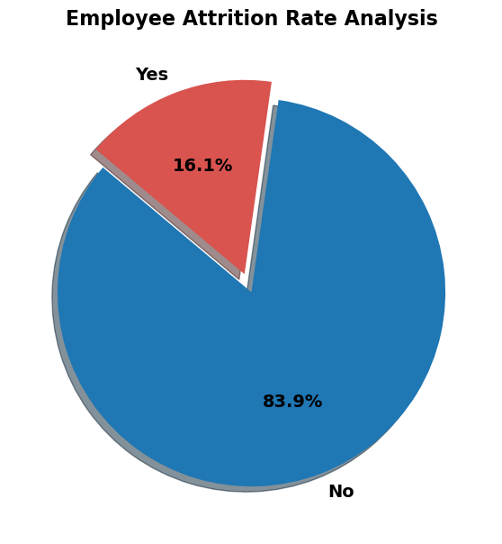

```python
# 1. Calculate and print the precise attrition rate
attrition_rate = (df["Attrition"] == "Yes").mean() * 100
print(f"Employee Attrition Rate: {attrition_rate:.2f}%\n")

# 2. Plot the Professional Pie Chart
attrition_counts = df["Attrition"].value_counts(normalize=True) * 100

# Make the 'Yes' slice pop out
explode = (0, 0.1) if attrition_counts.index[1] == 'Yes' else (0.1, 0)

plt.figure(figsize=(7, 7))
plt.pie(
    attrition_counts,
    labels=attrition_counts.index,
    autopct="%1.1f%%",
    startangle=140,
    explode=explode,
    shadow=True,
    colors=["#1f77b4", "#d9534f"], # Professional contrasting colors
    textprops={'fontsize': 14, 'weight': 'bold'} # Larger and bolder text
)

plt.title("Employee Attrition Rate Analysis", fontsize=16, weight='bold', pad=20)
plt.show()
```

### 💡 Key Findings & HR Insights:

- Overall Attrition: The company's overall employee attrition rate stands at 16.1% (237 employees left), while 83.9% (1,233 employees) chose to stay.
- Benchmark: A 16.1% turnover rate is within the standard industry average, but identifying specific risk factors can help lower this percentage further.

# Question 2: Which department has the highest employee attrition rate?

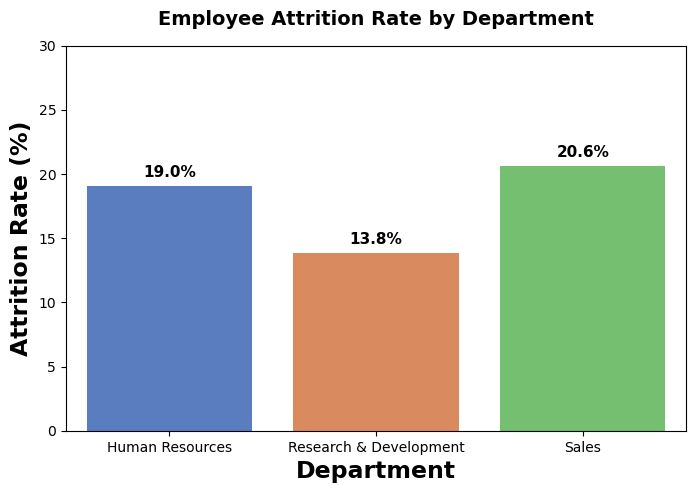

```python
# 2. Plot the actual Attrition Rate (Yes %) for each department
plt.figure(figsize=(8, 5))
sns.barplot(
    x=dept_attrition.index,
    y=dept_attrition['Yes'],
    hue=dept_attrition.index,
    legend=False,
    palette='muted'
)

plt.title('Employee Attrition Rate by Department', fontsize=14, weight='bold', pad=15)
plt.xlabel('Department', fontsize=17, weight='bold')
plt.ylabel('Attrition Rate (%)', fontsize=17, weight='bold')
plt.ylim(0, 30)

# Add data labels on top of each bar
for index, value in enumerate(dept_attrition['Yes']):
    plt.text(index, value + 0.5, f"{value:.1f}%", ha='center', va='bottom', fontsize=11, weight='bold')

plt.show()
```

### 💡 Key Findings & HR Insights:

- Highest Risk Department: The Sales department experiences the highest percentage of employee attrition relative to its size.
- Most Stable Department: The Research & Development (R&D) department shows the highest retention rate and stability.
- HR Recommendation: Investigate sales targets, commission structures, and department culture to understand why sales professionals are leaving at a higher rate.

# Question 3: Which job roles experience the highest employee turnover?

```
Attrition Rate by Job Role (%):

JobRole
Sales Representative         39.76
Laboratory Technician        23.94
Human Resources              23.08
Sales Executive              17.48
Research Scientist           16.10
Manufacturing Director        6.90
Healthcare Representative     6.87
Manager                       4.90
Research Director             2.50
Name: Yes, dtype: float64
```

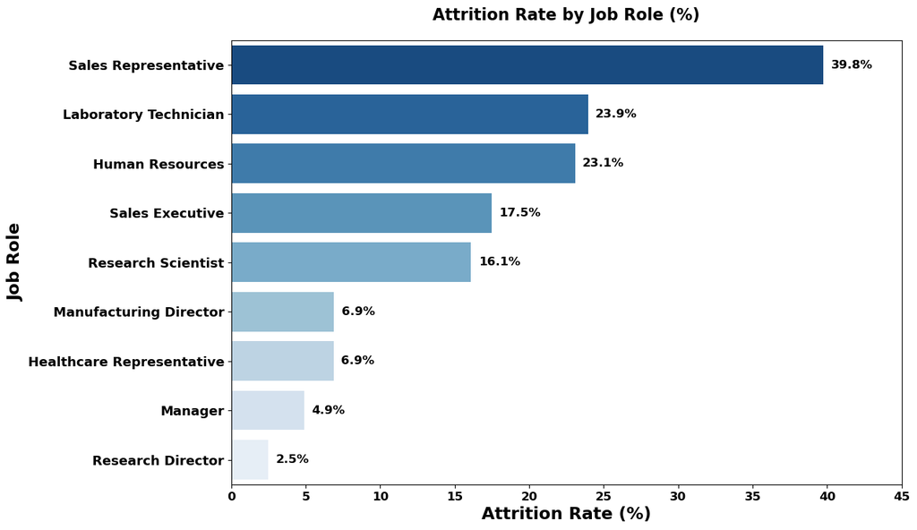

```python
# 1. Calculate and sort the precise attrition rate by job role
role_turnover = df.groupby('JobRole')['Attrition'].value_counts(normalize=True).unstack()['Yes'] * 100
role_turnover = role_turnover.sort_values(ascending=False)

print("Attrition Rate by Job Role (%):\n")
print(role_turnover.round(2))
print("\n")

# 2. Plot the professional horizontal bar chart with enlarged text
plt.figure(figsize=(12, 8)) # Increased size for long job titles and large text
sns.barplot(
    x=role_turnover.values,
    y=role_turnover.index,
    hue=role_turnover.index,
    legend=False,
    palette='Blues_r'
)

# Enlarge titles and axis labels
plt.title('Attrition Rate by Job Role (%)', fontsize=16, weight='bold', pad=20)
plt.xlabel('Attrition Rate (%)', fontsize=17, weight='bold')
plt.ylabel('Job Role', fontsize=17, weight='bold')
plt.xlim(0, 45)

# Enlarge side labels (Job Roles) and bottom ticks
plt.yticks(fontsize=13, weight='bold')
plt.xticks(fontsize=12, weight='bold')

# Enlarge percentage labels next to each bar
for index, value in enumerate(role_turnover.values):
    plt.text(value + 0.5, index, f"{value:.1f}%", va='center', ha='left', fontsize=12, weight='bold')

plt.show()
```

### 💡 Key Findings & HR Insights:

- Critical Job Roles: Sales Representatives are the most vulnerable group, with an alarming attrition rate close to 40%.
- Other High-Risk Roles: Laboratory Technicians and Human Resources roles also show elevated turnover rates.
- Senior Leadership Stability: Research Directors and Managers have the lowest attrition, showing almost 100% stability.

# Question 4: Does overtime work increase the likelihood of employee attrition?

```
Attrition Rate by Overtime Status (%):

Attrition     No    Yes
OverTime
No         89.56  10.44
Yes        69.47  30.53
```

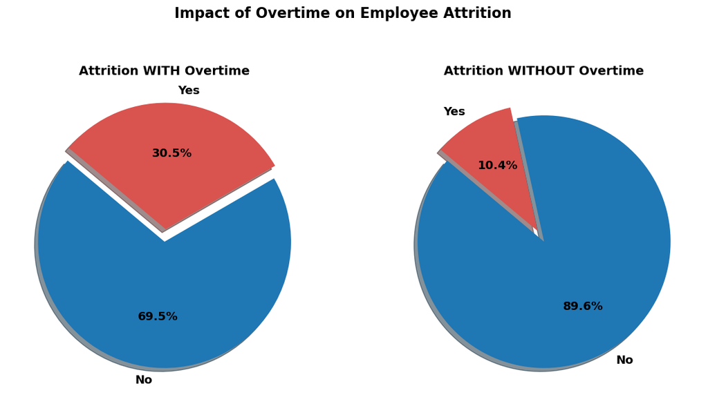

```python
# 1. Calculate and print the precise attrition rate by Overtime status
overtime_attrition = pd.crosstab(df['OverTime'], df['Attrition'], normalize='index') * 100
print("Attrition Rate by Overtime Status (%):\n")
print(overtime_attrition.round(2))
print("\n")

# 2. Setup the subplots for the two Pie Charts
fig, (ax1, ax2) = plt.subplots(1, 2, figsize=(14, 7))

# Chart 1: Attrition WITH Overtime
ax1.pie(
    overtime_attrition.loc['Yes'],
    labels=overtime_attrition.columns,
    autopct="%1.1f%%",
    startangle=140,
    explode=(0, 0.1),
    shadow=True,
    colors=["#1f77b4", "#d9534f"],
    textprops={'fontsize': 13, 'weight': 'bold'}
)
ax1.set_title("Attrition WITH Overtime", fontsize=14, weight='bold', pad=10)

# Chart 2: Attrition WITHOUT Overtime
ax2.pie(
    overtime_attrition.loc['No'],
    labels=overtime_attrition.columns,
    autopct="%1.1f%%",
    startangle=140,
    explode=(0, 0.1),
    shadow=True,
    colors=["#1f77b4", "#d9534f"],
    textprops={'fontsize': 13, 'weight': 'bold'}
)
ax2.set_title("Attrition WITHOUT Overtime", fontsize=14, weight='bold', pad=10)

plt.suptitle("Impact of Overtime on Employee Attrition", fontsize=16, weight='bold', y=1.02)
plt.show()
```

### 💡 Key Findings & HR Insights:

- Overtime Danger: Employees working Overtime have a massive attrition rate of 30.5%, compared to only 10.4% for those with standard working hours.
- The Attrition Multiplier: Requiring employees to work overtime nearly triples their likelihood of resigning from the company.
- HR Recommendation: Address burnout immediately. Limit continuous overtime, distribute workloads evenly, or introduce compensation restructuring for high-overtime roles.

# Question 5: How does employee age relate to attrition?

```
Average Age by Attrition Status:

Attrition
No     37.56
Yes    33.61
Name: Age, dtype: float64
```

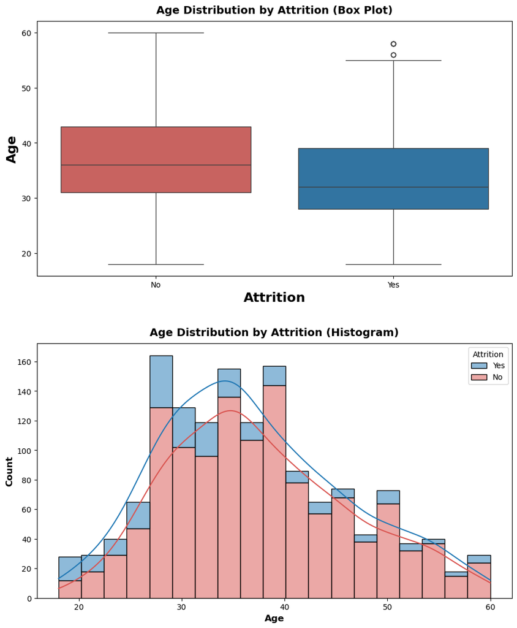

```python
# 1. Calculate and print the average age by Attrition status
average_age = df.groupby('Attrition')['Age'].mean()
print("Average Age by Attrition Status:\n")
print(average_age.round(2))
print("\n")

# 2. Setup the subplots (Box plot and Histogram)
fig, (ax1, ax2) = plt.subplots(2, 1, figsize=(10, 12))

# Chart 1: Box Plot for Age Distribution
sns.boxplot(
    x='Attrition',
    y='Age',
    data=df,
    order=['No', 'Yes'],
    hue='Attrition',
    legend=False,
    palette=['#1f77b4', '#d9534f'],
    ax=ax1
)
ax1.set_title('Age Distribution by Attrition (Box Plot)', fontsize=14, weight='bold', pad=10)
ax1.set_xlabel('Attrition', fontsize=17, weight='bold')
ax1.set_ylabel('Age', fontsize=17, weight='bold')

# Chart 2: Histogram for Age Distribution
sns.histplot(
    data=df,
    x='Age',
    hue='Attrition',
    multiple='stack',
    kde=True,
    palette=['#1f77b4', '#d9534f'],
    ax=ax2
)
ax2.set_title('Age Distribution by Attrition (Histogram)', fontsize=14, weight='bold', pad=10)
ax2.set_xlabel('Age', fontsize=12, weight='bold')
ax2.set_ylabel('Count', fontsize=12, weight='bold')

plt.tight_layout(pad=3.0)
plt.show()
```

💡 Key Findings & HR Insights:

- Younger Attrition: Attrition heavily spikes among younger employees, specifically between the ages of 25 and 31.
- Senior Stability: Older employees (above 40) show very high stability and rarely leave the company.
- HR Recommendation: Focus on engagement and clear career growth plans for young hires to decrease early-stage turnover.

# Question 6: Are employees with lower monthly income more likely to leave the company?

```
Average Monthly Income by Attrition Status:
Attrition
No     6832.739659
Yes    4787.092827
Name: MonthlyIncome, dtype: float64
```

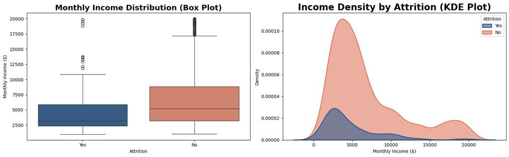

```python
# 1. Calculate and print the average monthly income for both groups
average_income = df.groupby("Attrition")["MonthlyIncome"].mean()
print("Average Monthly Income by Attrition Status:")
print(average_income)

# 2. Plot Box Plot and KDE Plot side by side
fig, axes = plt.subplots(1, 2, figsize=(16, 5))

# Left plot: Box Plot for salary ranges
sns.boxplot(
    data=df,
    x="Attrition",
    y="MonthlyIncome",
    hue="Attrition",
    palette=['#2b5c8f', '#e07a5f'],
    legend=False,
    ax=axes[0]
)
axes[0].set_title("Monthly Income Distribution (Box Plot)", fontsize=17, fontweight='bold')
axes[0].set_xlabel("Attrition")
axes[0].set_ylabel("Monthly Income ($)")

# Right plot: KDE Plot for salary density
sns.kdeplot(
    data=df,
    x="MonthlyIncome",
    hue="Attrition",
    fill=True,
    palette=['#2b5c8f', '#e07a5f'],
    alpha=0.6,
    linewidth=2,
    ax=axes[1]
)
axes[1].set_title("Income Density by Attrition (KDE Plot)", fontsize=20, fontweight='bold')
axes[1].set_xlabel("Monthly Income ($)")
axes[1].set_ylabel("Density")

plt.tight_layout()
plt.show()
```

### 💡 Key Findings & HR Insights:

# Question 7: Which income level has the lowest attrition rate?

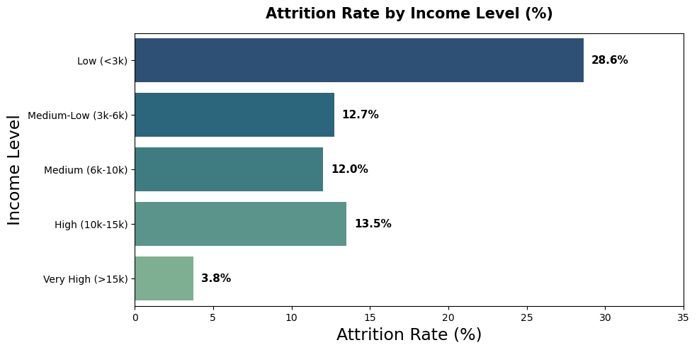

```python
# 1. Create income levels/bins
income_bins = [0, 3000, 6000, 10000, 15000, float('inf')]
income_labels = ['Low (<3k)', 'Medium-Low (3k-6k)', 'Medium (6k-10k)', 'High (10k-15k)', 'Very High (>15k)']
df['IncomeLevel'] = pd.cut(df['MonthlyIncome'], bins=income_bins, labels=income_labels)

# 2. Calculate attrition rate
income_attrition = pd.crosstab(df['IncomeLevel'], df['Attrition'], normalize='index')['Yes'] * 100

# 3. Plot the professional horizontal chart with clear data labels
plt.figure(figsize=(10, 5))
sns.barplot(
    x=income_attrition.values,
    y=income_attrition.index,
    hue=income_attrition.index,
    legend=False,
    palette='crest_r'  # تم وضع اسم الباليت مباشرة وببساطة هنا
)

plt.title('Attrition Rate by Income Level (%)', fontsize=15, weight='bold', pad=15)
plt.xlabel('Attrition Rate (%)', fontsize=17)
plt.ylabel('Income Level', fontsize=17)
plt.xlim(0, 35)

# Add precise percentage labels next to each bar
for index, value in enumerate(income_attrition.values):
    plt.text(value + 0.5, index, f"{value:.1f}%", va='center', ha='left', fontsize=11, weight='bold')

plt.show()
```

### 💡 Key Findings & HR Insights:

# Question 8: How does job satisfaction affect employee attrition?

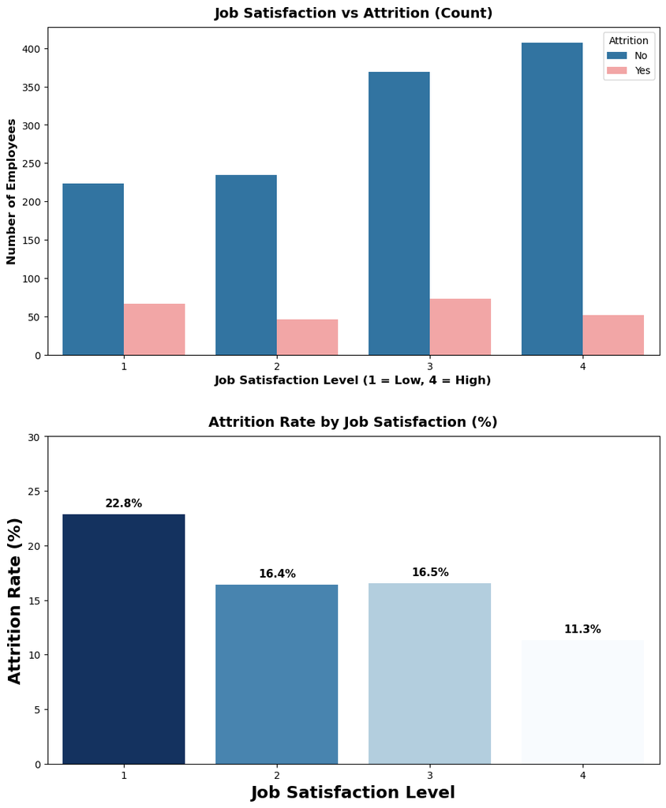

```python
# 1. Calculate the precise attrition rate by Job Satisfaction level
satisfaction_attrition = pd.crosstab(df['JobSatisfaction'], df['Attrition'], normalize='index') * 100

# 2. Setup the subplots (Count Plot and Bar Plot)
fig, (ax1, ax2) = plt.subplots(2, 1, figsize=(10, 12))

# Chart 1: Job Satisfaction vs Attrition (Count)
sns.countplot(
    x='JobSatisfaction',
    hue='Attrition',
    data=df,
    palette=['#1f77b4', '#ff9999'],
    ax=ax1
)
ax1.set_title('Job Satisfaction vs Attrition (Count)', fontsize=14, weight='bold', pad=10)
ax1.set_xlabel('Job Satisfaction Level (1 = Low, 4 = High)', fontsize=12, weight='bold')
ax1.set_ylabel('Number of Employees', fontsize=12, weight='bold')

# Chart 2: Attrition Rate by Job Satisfaction (%)
sns.barplot(
    x=satisfaction_attrition.index,
    y=satisfaction_attrition['Yes'],
    hue=satisfaction_attrition.index,
    legend=False,
    palette='Blues_r',
    ax=ax2
)
ax2.set_title('Attrition Rate by Job Satisfaction (%)', fontsize=14, weight='bold', pad=10)
ax2.set_xlabel('Job Satisfaction Level', fontsize=17, weight='bold')
ax2.set_ylabel('Attrition Rate (%)', fontsize=17, weight='bold')
ax2.set_ylim(0, 30)

# Add precise percentage labels on top of each bar
for index, value in enumerate(satisfaction_attrition['Yes']):
    ax2.text(index, value + 0.5, f"{value:.1f}%", ha='center', va='bottom', fontsize=11, weight='bold')

plt.tight_layout(pad=3.0)
plt.show()
```

### 💡 Key Findings & HR Insights:

- Low Satisfaction Risk: Employees with the lowest job satisfaction (Level 1) have the highest attrition rate, with nearly 23% of them leaving the company.
- High Satisfaction Stability: Employees with high job satisfaction (Level 4) show the greatest loyalty, with attrition dropping to around 11%.
- HR Recommendation: Conduct regular pulse surveys to capture early signs of dissatisfaction. Managers should step in with career development or role rotations when an employee reports low satisfaction.

# Question 9: Does work-life balance influence employee retention?

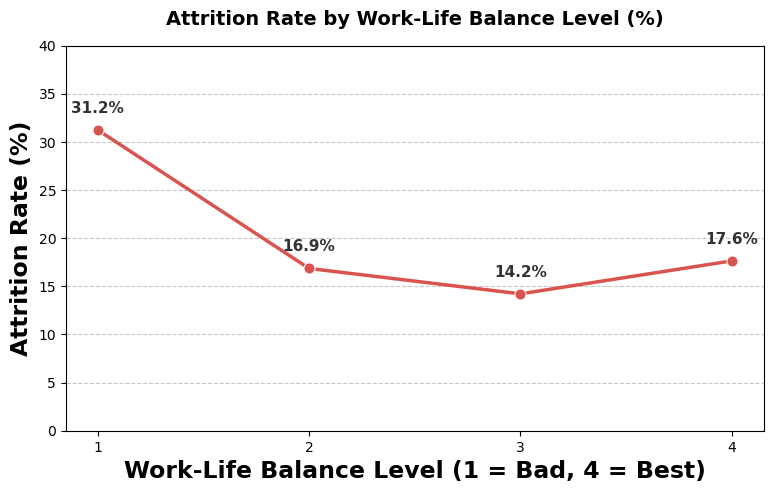

```python
# 1. Calculate the exact attrition rate per work-life balance level
wlb_attrition = df.groupby('WorkLifeBalance')['Attrition'].value_counts(normalize=True).unstack()['Yes'] * 100

# 2. Plot the line chart with clear data labels
plt.figure(figsize=(9, 5))
sns.lineplot(
    x=wlb_attrition.index,
    y=wlb_attrition.values,
    marker='o',
    markersize=8,
    color='#d9534f',
    linewidth=2.5
)

plt.title('Attrition Rate by Work-Life Balance Level (%)', fontsize=14, weight='bold', pad=15)
plt.xlabel('Work-Life Balance Level (1 = Bad, 4 = Best)', fontsize=17, weight='bold')
plt.ylabel('Attrition Rate (%)', fontsize=17, weight='bold')
plt.xticks(wlb_attrition.index)
plt.ylim(0, 40)
plt.grid(axis='y', linestyle='--', alpha=0.7)

# Add precise percentage labels above each data point
for x, y in zip(wlb_attrition.index, wlb_attrition.values):
    plt.text(x, y + 1.5, f"{y:.1f}%", ha='center', va='bottom', fontsize=11, weight='bold', color='#333333')

plt.show()
```

### 💡 Key Findings & HR Insights:

- The Burnout Danger Zone: Employees with poor work-life balance (Level 1) have a critical attrition rate of over 31%, making it one of the highest drivers of turnover in the company.
- The Sweet Spot: Attrition drops dramatically to around 14%-17% for employees who achieve moderate to good balance (Levels 2, 3 & 4).
- HR Recommendation: Implement flexible working hours or remote/hybrid options for departments suffering from high attrition to improve their work-life scores and prevent talent burnout.

# Question 10: What is the relationship between total working years and attrition?

```
Average Total Working Years by Attrition Status:

Attrition
No     11.86
Yes     8.24
Name: TotalWorkingYears, dtype: float64
```

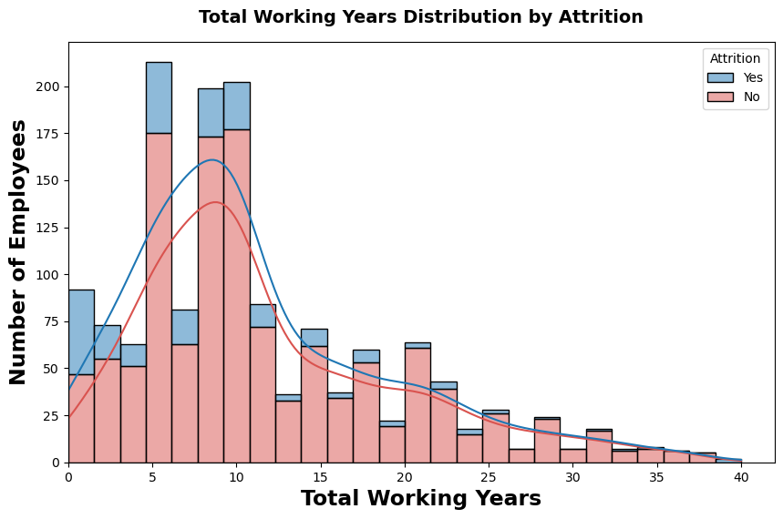

```python
# 1. Calculate and print the average total working years for both groups
average_working_years = df.groupby('Attrition')['TotalWorkingYears'].mean()
print("Average Total Working Years by Attrition Status:\n")
print(average_working_years.round(2))
print("\n")

# 2. Plot the distribution using Histogram and KDE
plt.figure(figsize=(10, 6))
sns.histplot(
    data=df,
    x="TotalWorkingYears",
    hue="Attrition",
    multiple="stack",
    kde=True,
    palette=['#1f77b4', '#d9534f']
)

plt.title('Total Working Years Distribution by Attrition', fontsize=14, weight='bold', pad=15)
plt.xlabel('Total Working Years', fontsize=17, weight='bold')
plt.ylabel('Number of Employees', fontsize=17, weight='bold')
plt.xlim(0, 42)

plt.show()
```

### 💡 Key Findings & HR Insights:

# Question 11: Are employees who have not received recent promotions more likely to leave?

```
Average Years Since Last Promotion by Attrition Status:

Attrition
No     2.23
Yes    1.95
Name: YearsSinceLastPromotion, dtype: float64
```

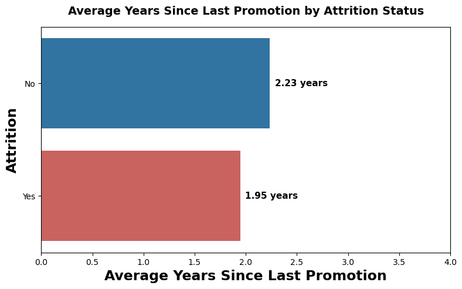

```python
# 1. Calculate and print the average years since last promotion
avg_promotion_years = df.groupby('Attrition')['YearsSinceLastPromotion'].mean()
print("Average Years Since Last Promotion by Attrition Status:\n")
print(avg_promotion_years.round(2))
print("\n")

# 2. Plot the professional horizontal bar chart with clear data labels
plt.figure(figsize=(9, 5))
sns.barplot(
    x=avg_promotion_years.values,
    y=avg_promotion_years.index,
    hue=avg_promotion_years.index,
    legend=False,
    palette=['#1f77b4', '#d9534f']
)

plt.title('Average Years Since Last Promotion by Attrition Status', fontsize=14, weight='bold', pad=15)
plt.xlabel('Average Years Since Last Promotion', fontsize=17, weight='bold')
plt.ylabel('Attrition', fontsize=17, weight='bold')
plt.xlim(0, 4.0)

# Add precise average values next to each bar
for index, value in enumerate(avg_promotion_years.values):
    plt.text(value + 0.05, index, f"{value:.2f} years", va='center', ha='left', fontsize=11, weight='bold')

plt.show()
```

### 💡 Key Findings & HR Insights:

- The Promotion Paradox: Interestingly, the data shows that employees who left the company actually had a lower average time since their last promotion (1.9 years) compared to those who stayed (2.2 years).
- Hidden Discontent: This proves that a lack of recent promotion is *not* a direct driver for overall attrition in the company. Employees are resigning despite being promoted recently, which heavily implies other factors like burnout (Overtime) or uncompetitive baseline salaries are responsible.
- HR Recommendation: Instead of assuming promotions solve retention issues, HR should investigate post-promotion workload, compensation adjustments, and role satisfaction, as talent is still draining shortly after upward mobility.

# Question 12: Does business travel frequency impact employee attrition?

```
Attrition Rate by Business Travel Frequency (%):

BusinessTravel
Travel_Frequently    24.91
Travel_Rarely        14.96
Non-Travel            8.00
Name: Yes, dtype: float64
```

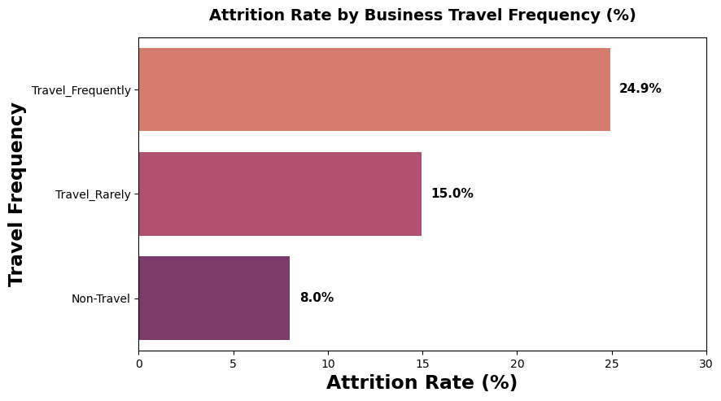

```python
# 1. Calculate the exact attrition rate per business travel category
travel_attrition = pd.crosstab(df['BusinessTravel'], df['Attrition'], normalize='index') * 100
travel_attrition = travel_attrition.sort_values(by='Yes', ascending=False)

print("Attrition Rate by Business Travel Frequency (%):\n")
print(travel_attrition['Yes'].round(2))
print("\n")

# 2. Plot the professional horizontal bar chart with clear data labels
plt.figure(figsize=(9, 5))
sns.barplot(
    x=travel_attrition['Yes'],
    y=travel_attrition.index,
    hue=travel_attrition.index,
    legend=False,
    palette='flare' # Maintaining your chosen warm color palette style
)

plt.title('Attrition Rate by Business Travel Frequency (%)', fontsize=14, weight='bold', pad=15)
plt.xlabel('Attrition Rate (%)', fontsize=17, weight='bold')
plt.ylabel('Travel Frequency', fontsize=17, weight='bold')
plt.xlim(0, 30)

# Add precise percentage labels next to each bar
for index, value in enumerate(travel_attrition['Yes']):
    plt.text(value + 0.5, index, f"{value:.1f}%", va='center', ha='left', fontsize=11, weight='bold')

plt.show()
```

### 💡 Key Findings & HR Insights:

- The Travel Fatigue: Employees who Travel Frequently have the highest attrition rate by far, reaching around 25%, which is significantly higher than the company baseline.
- Stable Segments: Employees who travel rarely (Travel Rarely) or do not travel at all (Non-Travel) show much lower and healthier attrition rates, at around 15% and 8% respectively.
- HR Recommendation: Frequent business travel is a major turnover accelerator. HR should look into travel fatigue support, introduce virtual meeting alternatives where possible, or offer travel-premium allowances to compensate employees for continuous disruption to their personal lives.

# Question 13: What is the average monthly income for each job role?

```
Average Monthly Income by Job Role ($):

JobRole
Manager                      17181.68
Research Director            16033.55
Healthcare Representative     7528.76
Manufacturing Director        7295.14
Sales Executive               6924.28
Human Resources               4235.75
Research Scientist            3239.97
Laboratory Technician         3237.17
Sales Representative          2626.00
Name: MonthlyIncome, dtype: float64
```

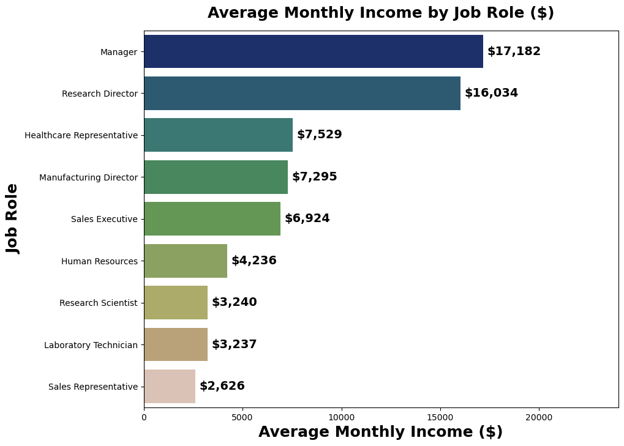

```python
# 1. Calculate and sort the average monthly income by job role
role_income = df.groupby('JobRole')['MonthlyIncome'].mean().sort_values(ascending=False)

print("Average Monthly Income by Job Role ($):\n")
print(role_income.round(2))
print("\n")

# 2. Plot the professional horizontal bar chart with clear data labels
plt.figure(figsize=(10, 8))
sns.barplot(
    x=role_income.values,
    y=role_income.index,
    hue=role_income.index,
    legend=False,
    palette='gist_earth'
)

plt.title('Average Monthly Income by Job Role ($)', fontsize=18, weight='bold', pad=15)
plt.xlabel('Average Monthly Income ($)', fontsize=18, weight='bold')
plt.ylabel('Job Role', fontsize=18, weight='bold')
plt.xlim(0, 24000)

# Add precise dollar labels next to each bar
for index, value in enumerate(role_income.values):
    plt.text(value + 200, index, f"${value:,.0f}", va='center', ha='left', fontsize=14, weight='bold')

plt.show()
```

### 💡 Key Findings & HR Insights:

# Question 14: Which job roles receive the highest salaries?

```
Top 5 Highest Paid Job Roles (Average Salary):

JobRole
Manager                      17181.68
Research Director            16033.55
Healthcare Representative     7528.76
Manufacturing Director        7295.14
Sales Executive               6924.28
Name: MonthlyIncome, dtype: float64
```

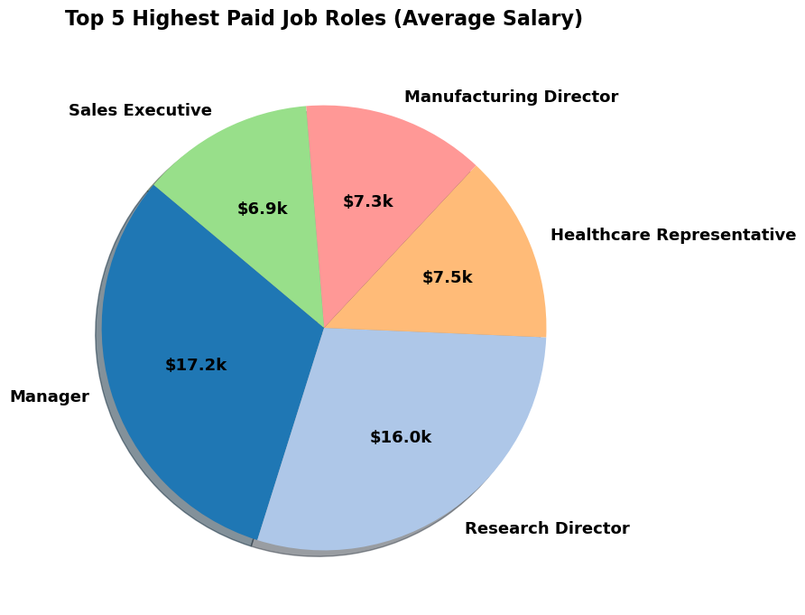

```python
# 1. Calculate and extract top 5 highest paid job roles
top_salaries = df.groupby('JobRole')['MonthlyIncome'].mean().sort_values(ascending=False).head(5)

print("Top 5 Highest Paid Job Roles (Average Salary):\n")
print(top_salaries.round(2))
print("\n")

# 2. Plot the professional Pie Chart for top 5 salaries
plt.figure(figsize=(8, 8))
plt.pie(
    top_salaries.values,
    labels=top_salaries.index,
    autopct=lambda p: f"${p*sum(top_salaries.values)/100000:.1f}k", # Displays formatting like $17.2k
    startangle=140,
    shadow=True,
    colors=['#1f77b4', '#aec7e8', '#ffbb78', '#ff9896', '#98df8a'],
    textprops={'fontsize': 13, 'weight': 'bold'}
)

plt.title('Top 5 Highest Paid Job Roles (Average Salary)', fontsize=16, weight='bold', pad=20)
plt.show()
```

### 💡 Key Findings & HR Insights:

- Top Salary Leader: Managers are the highest-paid individuals in the entire organization, commanding an impressive average monthly income of $17,181.
- The Runner-Up: Research Directors closely follow as the second highest-paid role, with an average monthly income of $16,033.
- The Retention Connection: These premium salary brackets perfectly explain our earlier findings; both roles showed a near-zero attrition rate. Competitive financial compensation proves to be 100% effective for senior talent retention.

# Question 15: What are the strongest factors associated with employee attrition?

```
Top Risk Factors Driving Employee Attrition (%):

Working Overtime     30.53
Low Income (<$3k)    28.61
Young Age (<30)      27.91
Frequent Travel      24.91
dtype: float64
```

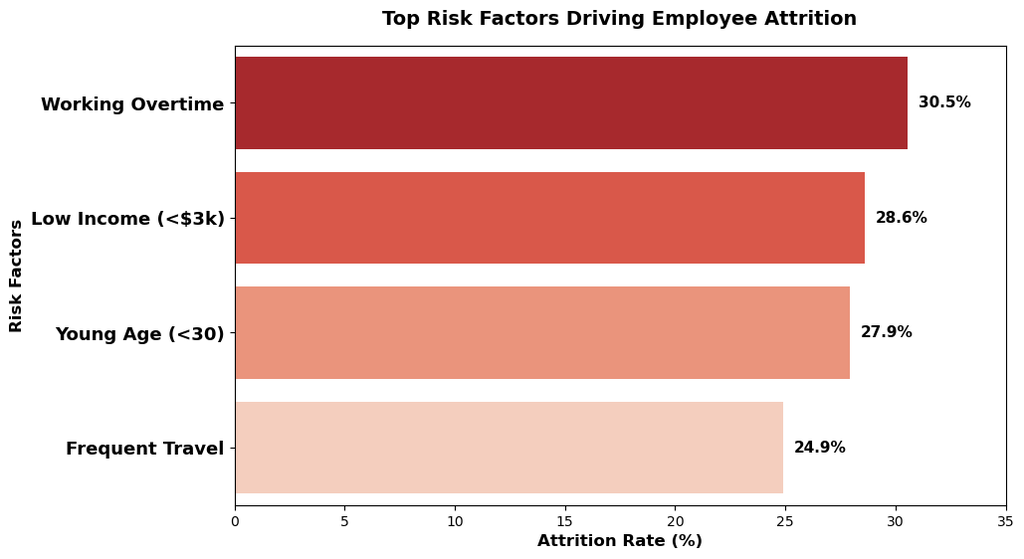

```python
# 1. Calculate the breakdown percentages dynamically from the dataset
overtime_rate = (df[df['OverTime'] == 'Yes']['Attrition'] == 'Yes').mean() * 100
low_income_rate = (df[df['MonthlyIncome'] < 3000]['Attrition'] == 'Yes').mean() * 100
young_age_rate = (df[df['Age'] < 30]['Attrition'] == 'Yes').mean() * 100
frequent_travel_rate = (df[df['BusinessTravel'] == 'Travel_Frequently']['Attrition'] == 'Yes').mean() * 100

# Combine into a sorted series
risk_factors = pd.Series({
    'Working Overtime': overtime_rate,
    'Low Income (<$3k)': low_income_rate,
    'Young Age (<30)': young_age_rate,
    'Frequent Travel': frequent_travel_rate
}).sort_values(ascending=False)

print("Top Risk Factors Driving Employee Attrition (%):\n")
print(risk_factors.round(2))
print("\n")

# 2. Plot the professional summary horizontal bar chart
plt.figure(figsize=(10, 6))
sns.barplot(
    x=risk_factors.values,
    y=risk_factors.index,
    hue=risk_factors.index,
    legend=False,
    palette='Reds_r'
)

plt.title('Top Risk Factors Driving Employee Attrition', fontsize=14, weight='bold', pad=15)
plt.xlabel('Attrition Rate (%)', fontsize=12, weight='bold')
plt.ylabel('Risk Factors', fontsize=12, weight='bold')
plt.xlim(0, 35)

# التعديل الجديد: تكبير خط المسميات ناحية الشمال وجعلها عريضة
plt.yticks(fontsize=13, weight='bold')

# Add precise percentage labels next to each summary bar
for index, value in enumerate(risk_factors.values):
    plt.text(value + 0.5, index, f"{value:.1f}%", va='center', ha='left', fontsize=11, weight='bold')

plt.show()
```

### 💡 Key Findings & HR Insights:

# Project Summary (HR Analysis)

# 🔴Key Problems Identified:

## 1.High Employee Attrition Rate (16.1%)

## A noticeable percentage of employees are leaving the company.

## 2.Sales Department has the Highest Turnovers

## Employees in Sales are leaving more than other departments.

## 3.Sales Representative Role is the Most Affected

## Nearly 40% attrition rate in this job role.

## 4.Overtime significantly increases attrition

## Employees working overtime are much more likely to resign.

## 5. Younger Employees are Leaving More

## Attrition is higher among younger age groups compared to older employees.

# 🟢 Suggested Solutions:

## 1.Improve Employee Retention Strategies

## Focus on understanding why employees leave through surveys and feedback.

## 2.Fix Issues in the Sales Department

## Review targets, pressure levels, and compensation system.

## 3.Reduce Overtime Pressure

## Balance workload and avoid continuous overtime to prevent burnout.

## 4.Improve Job Satisfaction in High-Risk Roles

## Especially for Sales Representatives and Laboratory Technicians.

## 5.Career Development & Training

## Provide growth opportunities for young employees to reduce turnover.